# Analysis of RNAseq data

2024 Workshop on Genomics, Cesky Krumlov

RA Steward

updated 2024-01

# 1 Our system: diet plasticity in generalist butterflies

Comma butterflies (*Polygonia c-album*) in Scandinavia can eat plants from several different families (Fig. 1). This kind of diet plasticity (generalization) is rare among herbivorous insects, butterflies in particular. The plants differ in both secondary chemistry and nutrition, suggesting that Comma larvae may use different molecular and physiological mechanisms to safely and efficiently metabolize tissue from these plants. We sequenced mRNA from the midguts of 4th instar larvae feeding on one of three different host plant genera: *Ribes* (gooseberry), *Salix* (willow) and *Urtica* (nettle) (Fig. 2).

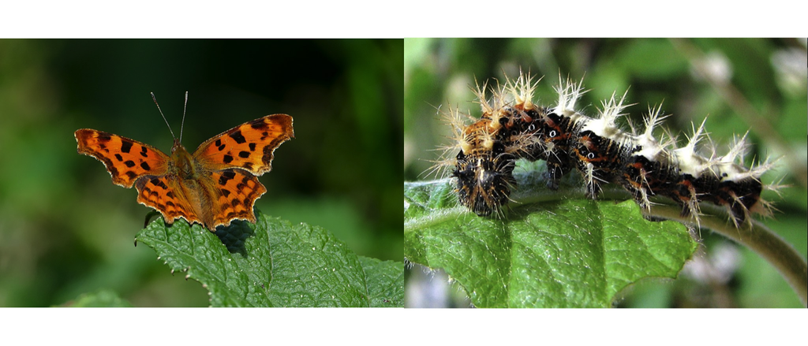

Fig. 1. Adult and larva of the Comma butterfly (© R. Tuinstra; © M. Flåten; https://commons.wikimedia.org)

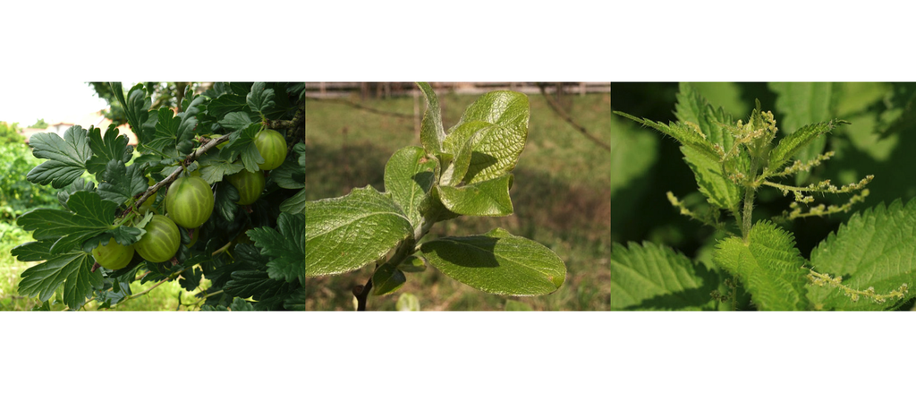

Fig. 2. *P. c-album* host plants: *Ribes uva-crispa* (gooseberry), *Salix caprea* (willow), and *Urtica dioica* (nettle). (https://botany.cz/)

# 2 Our questions

1. Do patterns of gene expression differ between larvae reared on different host plants?
2. Which genes are differently expressed between larvae reared on different host plants?
3. What are the functions of differentially expressed gene sets?

# 3 Background

This tutorial has three units:

- **Exploring patterns of gene expression among samples**
- **Identifying differentially expressed genes**
- **Evaluating functional enrichment of DE gene sets**

Each unit has core exercises you should try to finish during the lab. If you finish the core exercises, there are additional challenge exercises at the end of each unit.

Occasional blue boxes give background on the analyses. Feel free to gloss over these – you can come back to them later if you are curious or want to learn more.

# 4 Unit 1: Exploring patterns of gene expression among samples

Everything in this tutorial will be done in **RStudio**.

## 4.1 Set the working directory

Open RStudio and start by checking (`getwd()`) and setting (`setwd()`) your working directory. The activity is designed to be run in the `RNAseq_analysis” directory.

```r
#check your wd
getwd()

# if needed, set your wd. the activity is designed to be run in your main directory (aka $RNA_HOME from above)
setwd("/home/genomics/workshop_materials/RNAseq_analysis/")
```

Alternatively, you can set the working directory using the RStudio interface. Click on the `Files` tab. Navigate by clicking on the directories you want to enter (`workshop_materials`, then `RNAseq_analysis`). Once inside the working directory, use the `More` drop-down menu (next to the little blue gear) and select `Set As Working Directory`.

Take a look at the contents of the directory and subdirectory. You can do this using the `list.files()` command with the `recursive = T` option. or by selecting `Go To Working Directory` from the `More` drop-down menu on the `Files` tab.

```r
list.files(recursive = T)
```

The number of reads aligning to each gene can be found in the count file **diff_expr/Pcal_gene_counts.tsv**. Information about the samples can be found in the sample data file **sampledata/Pcal_sampledata.tsv**.

The remaining folders contain sequences and other reference files that will not be used in this tutorial.

## 4.2 Install and load packages

Our analysis will rely on several packages.

- `DESeq2`: differential gene expression analysis
- `topGO`: gene set enrichment anlaysis
- `magrittr`, `dplyr`, `tidyr`, `readr`, `tibble`: data wrangling
  - (or load the full `tidyverse`, if you prefer)
- `ggplot2`, `RColorBrewer`, `Rgraphviz`: visualizations

Luckily, they have already been installed on the virtual machine, so no need to install them now.

Use `library()` or `require()` to load the necessary packages.

```r
# load libraries
library("DESeq2")

# Or better yet, create a vector of the necessary packages and load them using lapply
myLib <- as.vector(c("DESeq2","topGO", "magrittr", "dplyr","tidyr", "readr", "tibble", "ggplot2", "forcats", "RColorBrewer"))

lapply(myLib,library,character.only=TRUE )
```

## 4.3 The data

### 4.3.1 Load the sample data

Remember that we are comparing expression among larvae feeding on different host plants (in the column `condition`). We also evenly sampled larvae from three different families. **First, load the sample data into the working environment.** You can use different packages and functions to do this, but we will use `readr::read_tsv()`.

```r
# readr::read_tsv() to load the sample data
Pcal_sampledata <- read_tsv("sampledata/Pcal_sampledata.tsv",
                          col_types = c("ccfff"))

# here we specify the column types using a condensed string, one letter for each column.
# 'c' stands for character, 'f' for factor
```

**Optional**: Inspect the sample data using `str()`, `head()` and `summary()`. Alternatively, click on `Pcal_sampledata` in the `Environment` tab of the RStudio interface.

```r
str(Pcal_sampledata)
head(Pcal_sampledata)
summary(Pcal_sampledata)
unique(Pcal_sampledata$sampleName) %>% length()
```

We have three individuals in each family-condition combination.

```r
table(Pcal_sampledata[3:4])
```

```
##          family
## condition 1 2 3
##    Ribes  3 3 3
##    Salix  3 3 3
##    Urtica 3 3 3
```

This is a little slim for a differential expression analysis. Many DGE tools, including `DESeq2` recommend 7 or more samples in each group. Therefore, we are going to stick with looking at differences between host plants (`condition`) in this activity.

### 4.3.2 Load the count data

Load the count data into the working environment and convert it into a matrix.

```r
# load gene count data, convert the column gene_id to row names, convert to a matrix
Pcal_counts <- read_tsv("diff_expr/Pcal_gene_counts.tsv") %>%
  column_to_rownames("gene_id") %>%
  as.matrix()
```

```r
# compare matrix column names with sample names
colnames(Pcal_counts) %in% Pcal_sampledata$sampleName
```

All of the values should be `TRUE`.

### 4.3.3 Create the DESeq object

Now we create the data object necessary for `DESeq2` to analyze the data.

Some R packages (esp. Bioconductor packages) define and use custom classes within R for storing data (input data, intermediate data and also results). These custom data structures are similar to lists in that they can contain multiple different data types/structures within them. Unlike lists, they have pre-specified data slots to hold specific types or classes of data. The data stored in these pre-specified slots can be accessed using functions designed and implemented specifically for the package.

To create the `DESeqDataSet` object, we will need the count matrix (`Pcal_counts`) and the sample data frame (`Pcal_sampledata`) as input.

We will also need to specify a **design formula**. The design formula describes how the column(s) in the sample data frame should be used in the analysis. For our data, we only have one column we are interested in: `condition.` The design `~ condition` tells `DESeq2` that we want to evaluate gene expression change with respect to the three different levels of this variable.

Create the `DESeqDataSet` (aka `dds`) object:

```r
Pcal_dds <- DESeqDataSetFromMatrix(countData = Pcal_counts,
                              colData = Pcal_sampledata,
                              design = ~ condition)
# Take a look:
Pcal_dds
```

If you check out some of the other DESeq2 import functions with `help("DESeqDataSet-class")`, you can see that `DESeq2` has a function to import `HTSeq` count files directly (`DESeqDataSetFromHTSeqCount`) which can streamline your pipeline a bit. Or, if you have used a pseudo-aligner like Salmon and have transcript abundance estimates, these can also be imported directly (`DESeqDataSetFromTximport`).

## 4.4 Normalization

There can be **systematic biases** in RNA sequencing data, such as differences in total sequencing depth between samples. We need to adjust the count data for such systematic biases in a process called normalization.

### 4.4.1 Optional filtering

DGE analysis is designed to deal with count data that is highly variable among samples and genes. However, it is sometimes a good idea to remove genes that are very rarely expressed *before* you start your analysis. This can:

- improve model fit
- reduce the number of multiple comparisons (see below).

```r
# determine whether genes meet our threshold
keep <- rowSums(counts(Pcal_dds) >= 5 ) >= 9

# filter the dds object to keep genes that meet the threshold
Pcal_dds_filt <- Pcal_dds[keep,]

# if you plan to use the filtered data set, make sure you use the filtered dds object in the following analysis
```

How many genes did not meet the filtering criteria?

```r
# check the number of genes that meet our threshold (== TRUE)
table(keep)
```

### 4.4.2 Normalize the counts within the `dds` object

The main factors considered during normalization are sequencing depth and RNA composition. `DESeq2` uses the *Median of Ratios normalization* (MRN) method. If you’re interested, you can find a detailed explanation of how MRN is calculated in the supplementary slides of the presentation. Here are the basic steps:

1. A pseudo-reference sample is created for each gene by taking the rowwise geometric mean.
2. The ratio is calculated of each sample in relation to this pseudo-reference.
3. A normalization factor (aka **size factor**) is calculated from the median value of all ratios for each column.
4. Normalized count values are calculated using the normalization factor.

Estimate the size factors for each sample:

```r
# Estimate the size factors
Pcal_dds <- estimateSizeFactors(Pcal_dds)
sizeFactors(Pcal_dds) # Check the size factors
```

Based on the size factor calculated for Pcal_Ribes_rep6, were read counts in this sample systematically lower or higher than expected?

## 4.5 Unsupervised clustering

Now that we have the normalized counts, we can perform quality control and exploratory analysis using unsupervised clustering. These analyses include *Principal Component Analysis* (PCA) and *hierarchical clustering*.

PCA is a technique used to emphasize variation and bring out strong patterns in the data. We expect to see biological replicates belonging to the same experimental group to cluster together.

Hierarchical clustering also groups samples by expression similarity. A hierarchical tree indicates which samples are more similar to each other based on the normalized gene expression values. A heatmap is used to show the correlation of gene expression for all pairwise combinations of samples in the data. Clustering of samples in the hierarchical clustering analysis should be similar to clustering in the PCA.

### 4.5.1 Transformation

When using unsupervised clustering methods, transformation of the normalized counts improves the estimated correlations or distances between samples or genes for visualization. `DESeq2` recommends a variance-stabilizing transformation (`vst()`) of the normalized counts.

```r
# Transform the data using the variance-stabilizing transformation
Pcal_vst <- vst(Pcal_dds, blind=TRUE)
```

Here we have set blind to `TRUE` because we want the transformation to be performed without considering the design formula of the `dds` object. If conditions are expected to be VERY different in their total counts, it is a good idea to change this to `blind == FALSE`. For example, a pupa in the middle of winter is performing few physiological processes other than homeostasis and has very low transcription. In contrast, a pupa that is right about to emerge as an adult butterfly is undergoing massive morphological and physiological changes and has much higher levels of transcription. In this case, it is better to use `blind == FALSE`.

### 4.5.2 Principal component analysis

Create a PCA using the `DESeq2` function `plotPCA()`. We will focus on the 1000 most variable genes (~10% of expressed genes) by setting the option `ntop = 1000`. The default is 500.

```r
# PCA plot
plotPCA(Pcal_vst, intgroup=c("condition"), ntop = 1000)

# plotPCA depends on ggplot2, so we can spice it up a bit:
plotPCA(Pcal_vst, intgroup=c("condition"), ntop = 1000) +
  theme_bw() +
  scale_color_brewer(palette = "Dark2", name = "Host plant") +
  theme(legend.text = element_text(face = "italic"))

# save your plot
ggsave("output/Pcal_vst_PC1_PC2.pdf", height = 6, width = 6)
```

*Hint: If you don’t like using the `DESeq2::plotPCA()` function and want to use a one that might be a little more customizable (e.g., `stats::prcomp()` or `FactoMineR::PCA()`), you can extract the normalized, transformed values using `assay(Pcal_vst)`.*

### 4.5.3 Hierarchical clustering

Here, we are going to visualize which samples cluster together when using all of the filtered, normalized and transformed expression data. Start by creating a distance matrix among samples using `stats::dist()`.

```r
# Create the distance matrix
Pcal_vst_dists <- dist(t(assay(Pcal_vst)))
Pcal_vst_mat <- as.matrix(Pcal_vst_dists)
```

Now, run the clustering analysis on the samples using the function `stats::hclust()`.

```r
# run clustering analysis
Pcal_vst_hc <- hclust(Pcal_vst_dists)
```

```r
# create a color palette
hmcol <- colorRampPalette(brewer.pal(9, "GnBu"))(100)

# Plot the heatmap
Pcal_hm <- heatmap(Pcal_vst_mat,
        Rowv=as.dendrogram(Pcal_vst_hc),
        symm=TRUE,
        col = rev(hmcol),
        margin=c(13, 13),
        cexRow = 0.75,
        cexCol = 0.75)
```

```r
# save the heatmap
pdf(file = "output/Pcal_vst_sampleHeatmap.pdf", height = 6, width = 6)
heatmap(Pcal_vst_mat,
        Rowv=as.dendrogram(Pcal_vst_hc),
        symm=TRUE,
        col = rev(hmcol),
        margin=c(13, 13),
        cexRow = 0.75,
        cexCol = 0.75)
dev.off()
```

*Hint: note that `pheatmap` condenses the column and row axis labels. Don’t be worried if you can only see a fraction of your samples. Instead, save your figure at a large enough scale that all of your samples are shown in the axis labels.*

## 4.6 Challenge exercises

### 4.6.1 Create a PCA biplot

How can we make the PCA more informative? One option is to add vectors that represent the major genes that contribute to the position of samples in principal component space.

`DESeq2::plotPCA` is a wrapper that both calculates and plots the PCs, which makes it difficult to pull additional information. We can recreate the PCA results on our own.

First, extract the normalized values from the `dds` object using the `DESeq2` function `assay()`, calculate the variances with `var()` and subset the top 1000 most variable genes.

```r
ntop = 1000

Pcal_vst_mat <- assay(Pcal_vst)
Pcal_vst_ntop_names <-names(sort(apply(Pcal_vst_mat, 1, var), decreasing = T))[1:ntop]
Pcal_vst_ntop <- t(Pcal_vst_mat[Pcal_vst_ntop_names,])
```

Calculate the principal components of the top 1000 genes with the `stats` function `prcomp()`.

```r
# calculate principal components
Pcal_vst_pca <- prcomp(Pcal_vst_ntop)

# make sure they match the PCA you made with plotPCA by looking at the summary of the PCA object. Does the proportion of the variance explained by PC1 match the % on the x axis from earlier?
summary(Pcal_vst_pca)
```

Pull the proportion of the variance for the first and second PC axes from the `summary()` object.

```r
pc1_prop <- summary(Pcal_vst_pca)$importance[2,1]
pc2_prop <- summary(Pcal_vst_pca)$importance[2,2]
```

Create a data frame of principal component values for each sample, which can be found in `Pcal_vst_pca$x`. Join the sample data to the data frame (e.g., using `tidyr::left_join`).

```r
Pcal_vst_pca_df <- as.data.frame(Pcal_vst_pca$x) %>%
  rownames_to_column(var = "sampleName") %>%
  left_join(dplyr::select(Pcal_sampledata, sampleName, condition, family))
```

Create a data frame of loadings for each gene, which can be found in `Pcal_vst_pca$rotation`. Subset the data frame to focus on 10 most variable genes (use the `Pcal_vst_ntop_names` vector we made before).

```r
Pcal_vst_pca_loadings <- as.data.frame(Pcal_vst_pca$rotation[Pcal_vst_ntop_names,])%>%
  rownames_to_column(var = "geneID") %>%
  head(10)
```

Now we can build a plot with both of these data frames. We will multiply the gene loadings by 200 so they are visible on the same scale as the sample points.

```r
ggplot() +
  geom_point(data = Pcal_vst_pca_df,
             aes(x = PC1, y = PC2, color = condition, shape = family)) +
  geom_segment(data = Pcal_vst_pca_loadings,
               aes(x=0, y=0, xend=PC1*200, yend=PC2*200),
               arrow = arrow(length=unit(0.5, 'cm')), color = "red") +
  annotate(geom = "text",
           label = Pcal_vst_pca_loadings$geneID,
           x = Pcal_vst_pca_loadings$PC1*200, y = Pcal_vst_pca_loadings$PC2*200,
           size = 3)+
  theme_bw() +
  labs( x = paste0("PC1 (", signif(pc1_prop*100,3), "%)"),
        y = paste0("PC1 (", signif(pc1_prop*100,3), "%)")) +
  scale_color_brewer(palette = "Dark2", name = "Host plant") +
  theme(legend.text = element_text(face = "italic"))

# here I added shape = family as an option within the geom_point aesthetic just to check that PC1 isn't a genetic difference
```

### 4.6.2 Create a multidimensional scaling plot (MDS)

While PCA is a common and widely used dimension reduction analysis in RNAseq data analysis. But, it makes a lot of assumptions about the data structure that aren’t always correct.

```r
library(vegan)
ntop = 1000

Pcal_vst_mat <- assay(Pcal_vst)
Pcal_vst_ntop_names <-names(sort(apply(Pcal_vst_mat, 1, var), decreasing = T))[1:ntop]
Pcal_vst_ntop <- t(Pcal_vst_mat[Pcal_vst_ntop_names,])

Pcal_vst_ntop_dist <- vegdist(Pcal_vst_ntop)
Pcal_vst_ntop_mds <- monoMDS(Pcal_vst_ntop_dist, model = "loc")
Pcal_vst_ntop_mds_df <- Pcal_vst_ntop_mds$points %>%
  as.data.frame() %>%
  rownames_to_column("sampleName") %>%
  left_join(Pcal_sampledata)

ggplot(Pcal_vst_ntop_mds_df, aes(x = MDS1, y = MDS2) ) +
  geom_point(aes(color = condition, shape = family)) +
  theme_bw()

# here I added shape = family as an option within the geom_point aesthetic just to check that PC1 isn't a genetic difference
```

# 5 Unit 2: Differential gene expression analysis

Now that we have checked our samples for outliers and explored patterns of clustering using dimension reduction and clustering, we will conduct **differential expression analysis**. To run the actual analysis, we use the function `DESeq()`. It performs the normalization of the counts using the size factors, estimates dispersion, and fits the linear model. Run `DESeq2()` on the `dds` object. Use the assign arrow (`<-`) to replace the old `dds` object with the newly fitted object.

```r
# Run the analysis on the filtered read counts
Pcal_dds <- DESeq(Pcal_dds)
```

By re-assigning the results of the function back to the same variable name (`Pcal_dds`), we can fill in the slots of our `DESeqDataSet` object with the new values calculated by `DESeq2`.

## 5.1 Identifying DE genes

With `DESeq2`, the *Wald test* is commonly used for hypothesis testing when comparing two groups. To indicate to `DESEq2` the two groups we want to compare, we provide **contrasts**, or the specific pair of groups we want to test.

First, we have to check what contrasts are possible given our data and design formula.

```r
# check what contrasts are even possible
resultsNames(Pcal_dds)
```

*Ribes* is currently set as the base level in our variable `condition`, so `DESeq2` automatically compares the remaining two levels back to *Ribes*.

**Extract the results for *Urtica* vs. *Ribes***.

```r
# specify the contrast by naming the factor you want to test
# and the levels of the factor you want to compare.
contrast_U_R <- c("condition", "Urtica", "Ribes")

# extract the results for your specified contrast
Pcal_res_table_U_R <- results(Pcal_dds, contrast=contrast_U_R)

# this can alternatively be written using the names of the contrasts
Pcal_res_table_U_R <- results(Pcal_dds, name = "condition_Urtica_vs_Ribes") # do not run this code, the results are the same as the previous line
```

A Wald test statistic is computed per-gene, and evaluates the probability that a test statistic at least as extreme as the observed value would occur at at random. We reject the null hypothesis (i.e. there is no difference in expression between groups) and conclude a gene is differentially expressed when the calculated p-value is below our significance threshold (usually 0.05).

```r
# sort results based on the padj
Pcal_res_table_U_R <- Pcal_res_table_U_R[order(Pcal_res_table_U_R$padj),]

# You will now have the smallest padj values at the top of your table
head(Pcal_res_table_U_R)

# save your results
write_tsv(as.data.frame(Pcal_res_table_U_R), "output/Pcal_res_table_U_R.tsv")
```

The column headers are:

- `baseMean`: mean of normalized counts for all samples
- `log2FoldChange`: log2 fold change or LFC
- `lfcSE`: standard error of log2 fold change
- `stat`: the Wald test statistic
- `pval`: Wald test p-value
- `padj`: Benjamini-Hochberg (BH) adjusted p-values

We will use adjusted p-value to identify significantly differentially expressed genes. We can use additional thresholds, like log2 fold change (LFC), to identify DE genes. A common threshold is an absolute LFC of 1, which means expression of that gene is twice as much in one of the conditions compared to the other.

Note that we have p-values (`pval`) and adjusted p-values (`padj`) in the output. When we use the p-values and a significance threshold of 0.05, we are likely making a wrong conclusion (for example, believing a gene is significantly differentially expressed) for 1 out of every 20 genes. Now, what if we are testing 100 genes? We are probably making ~5 wrong conclusions. 10,000 genes? ~500 wrong conclusions. Adjusting the p-values to account for testing multiple genes helps us to have more confidence in our conclusions.

## 5.2 Visualizing DE genes

### 5.2.1 Individual genes

To make sure we understand the results, it is good to start by looking at a single gene. Inspect the gene that is *most* differentially expressed (i.e., lowest padj) in the sorted results table using `head()`.

```r
head(Pcal_res_table_U_R, 1)
```

Is it up or down-regulated in larvae feeding on *Ribes* compared to *Urtica*? It can be hard to tell from the results tabe alone. We can use `DESeq2::plotcounts()` on the `dds` object to visualize differences in expression for larvae on different host plants. Make sure to use the option `gene=` to identify the gene of interest, and `intgroup = "condition"` to plot expression by host plant on the x-axis.

```r
plotCounts(Pcal_dds, gene="Polcal_g14648", intgroup="condition")
```

From this plot, we can see that the top expressed gene (which had an LFC of -7.88699 in the results table) is expressed at lower levels on *Urtica* than on *Ribes*. This tells us that genes with negative LFC values and significant adjusted p-values (based on our chosen cutoff) are likely to be downregulated on *Urtica* and upregulated on *Ribes*.

Thus, we can think of the contrast `c("condition", "Urtica", "Ribes")` as asking the question `How does *Urtica* (condition 1) differ relative to *Ribes* (condition 2), which should help when trying to specify your own contrasts.

### 5.2.2 All genes: MA plot

The MA plot shows the mean of the normalized counts (x-axis) versus the LFC (y-axis) for all genes. Genes that are significantly differentially expressed are colored to be easily identified. The default significance threshold is 0.05, but today let’s use **p < 0.01** to be a little more conservative. Remember, negative LFC values mean the genes are less expressed in *Urtica*!

To make an MA plot directly from the `DESeq` object, we use the function `plotMA()`. Use `??DESeq2::plotMA` to figure out how create this plot.

```r
# MA plot needs the dds object
plotMA(object = Pcal_dds,
       ylim=c(-2,2),
       alpha = 0.01)
```

*Note that the triangles show genes that fall outside of our y axis limits. Try changing the `ylim` values to see how the number of triangles changes.*

**Extra challenge**: build the plot in ggplot instead. *Quick reminder: the results table is a `DESeqResults` object, but ggplot() requires a dataframe. Convert your results table to a dataframe (`as.data.frame()`) before using it in ggplot.*

```r
# ggplot option
ggplot(as.data.frame(Pcal_res_table_U_R), aes(x = log(baseMean), y = log2FoldChange)) +
  geom_point(aes(color = padj < 0.01), size = 0.5) +
  scale_color_manual(values = c("grey", "blue"))+
  theme_bw()
# ggsave option
ggsave("output/Pcal_MAplot_U_R.pdf", height = 6, width = 6)
```

Once you’re happy with it, save your plot using the `pdf()` device or `ggsave()`.

This plot allows us to evaluate the magnitude of fold changes and how they are distributed relative to mean expression. Generally, we would expect to see significant genes across the full range of expression levels. Do you observe this in your plot?

When within-group variation is high, LFC values can be a little misleading. Just look at all the nonsignificant genes with very high or low LFC in our MA and volcano plots. In this example data set, you have lots of genes with very small count numbers (between 0 to 10) that also have large log2fold changes (>1). Using `DESeq2`, there is a way to shrink the log2 fold change for genes with low counts so that you can have more confidence in the fold change estimates. You can have a look on documentation and read about log2 fold change shrinkage.

### 5.2.3 All genes: Volcano plot

The volcano plot builds on the MA plot by visualizing the relationship between LFC (x-axis) and padj (-log10-transformed (`-log10(padj)`) on the y-axs). Use `ggplot()` and `geom_point()` to create a volcano plot.

*Quick reminder: the results table is a `DESeqResults` object, but ggplot() requires a dataframe. Convert your results table to a dataframe (`as.data.frame()`) before using it in ggplot.*

```r
ggplot(as.data.frame(Pcal_res_table_U_R),
       aes(x = log2FoldChange, y = -log10(padj))) +
 geom_point()
```

#### 5.2.3.1 Make it fancy!

We can make this plot *much* more informative to readers.

- Use `geom_hline()` to add a dashed horizontal line at our significance threshold (p = 0.01, but don’t forget the adjusted p-values are -log10-transformed!)
- Use `geom_vline()` to add dashed vertical lines at our LFC threshold (-1 and 1)
- **Extra challenge:** Color the points by whether they are significantly DE or not
  - you can do this by creating a new variable in the results table or by changing how you plot the points within ggplot.

```r
# option 1
Pcal_res_df_U_R <- Pcal_res_table_U_R %>%
  as.data.frame() %>%
  mutate(sigDE = if_else(padj < 0.01 & abs(log2FoldChange) > 1 , "sig", "nsig"))

ggplot(as.data.frame(Pcal_res_df_U_R), aes(x = log2FoldChange, y = -log10(padj))) +
 geom_point(aes(color = sigDE)) +
  scale_color_manual(values = c("grey", "blue"))+
  geom_hline(yintercept = -log10(0.01), linetype = "dashed")+
  geom_vline(xintercept = c(-1, 1), linetype = "dashed") +
  theme_bw()

## option 2
ggplot() +
  geom_point(
    data = as.data.frame(Pcal_res_table_U_R) %>%
      filter(padj > 0.01 | abs(log2FoldChange) < 1),
    aes(x = log2FoldChange, y = -log10(padj)),
    color = "grey") +
  geom_point(
    data = as.data.frame(Pcal_res_table_U_R) %>%
      filter(padj < 0.01 & abs(log2FoldChange) > 1),
    aes(x = log2FoldChange, y = -log10(padj)),
    color = "blue") +
  geom_hline(yintercept = -log10(0.01), linetype = "dashed") +
  geom_vline(xintercept = c(-1, 1), linetype = "dashed") +
  theme_bw()

# save the volcano plot
ggsave("output/Pcal_volcanoPlot_U_R.pdf", height = 6, width = 6)
```

Volcano plots also give us an opportunity to see whether our results look “normal”. If we see big lines or streaks of genes all in a row, this might mean we have a lot of duplicated loci in our assembly or that our model doesn’t fit our data very well.

## 5.3 Challenge exercises

### 5.3.1 Heat map of differentially expressed genes.

Another useful visualization tool is a heatmap of gene expression. We used heatmaps above to show correlations between samples. We can also use heatmaps to show expression of significantly DE genes using `heatmap()`. Heatmaps contain a lot of information, so it is usually a good idea to use a subset of genes that interest you.

Make a heatmap of the 50 most differentially expressed (lowest p-value) genes:

- subset the resuls table to only include significantly differentially epxpressed genes using an absolute log2 fold change cutoff of 1 (`abs(log2FoldChange) > 1`) and an adjusted p-value cutoff of 0.01.
- create a list of the 50 most differentially expressed gene IDs from your results table
- subset the VST transformed expression matrix to include only the rows for these 50 genes.
- make a heatmap of this subset using `pheatmap.
- save your result using the `pdf()` device

```r
# Identify the top 50 differentially expressed genes from the sorted results table.
DE_genes_df <- Pcal_res_table_U_R %>%
  as.data.frame() %>%
  rownames_to_column("geneID") %>%
  filter(padj  < 0.01 & abs(log2FoldChange) > 1)

DE_genes_top50 <- DE_genes_df$geneID %>%
  head(50)

# Extract the expression levels of the most expressed genes from the vst-transformed dds object
Pcal_vst_DE_top50_U_R <- assay(Pcal_vst)[rownames(Pcal_vst) %in% DE_genes_top50,]

# create the heatmap using baseR heatmap
heatmap(Pcal_vst_DE_top50_U_R,
        margin = c(10,6))

# save plot
pdf(file = "output/Pcal_geneHeatmap_U_R.pdf", height = 6, width = 6)
heatmap(Pcal_vst_DE_top50_U_R,
        margin = c(10,6))
dev.off()
```

### 5.3.2 Identify sub-groups of differentially expressed genes with fuzzy clustering

Subset the VST transformed expression matrix to include only your differentially expressed genes.

```r
Pcal_vst_DE_U_R <- assay(Pcal_vst)[rownames(Pcal_vst) %in% DE_genes_df$geneID,]
```

We are going to use a package called Mfuzz to perform the fuzzy clustering. This requires that we save the matrix in a temporary file before reloading it as an `ExpressionSet` (custom class in R) using the function `table2eset()`

```r
library(Mfuzz)
tmp <- tempfile()
write.table(Pcal_vst_DE_U_R,file=tmp, sep='\t', quote = F, col.names=NA)

#read it back in as an expression set
dat <- table2eset(file=tmp)
```

```r
dat.s <- standardise(dat)

# you can remove the unscaled expressionSet
rm(dat)
```

Fuzzy c-means clustering is similar to kmeans clustering, which assigns genes to a predefined number of clusters based on their expression. But in fuzzy clustering, the membership assignments are allowed a certain amount of fuzziness: genes can be assigned to multiple clusters at once. This means that genes with unclear membership won’t have an undue effect on the composition of the clusters to which they are assigned (Schwämmle & Jensen, 2010).

Calculate the fuzzifier, or the amount of fuzziness that will be allowed when assigning membership using `mestimate()`.

```r
m1 <- mestimate(dat.s)
m1
```

We still have to provide the number of clusters we expect to see in the data. We can do this by calculating the minimum centroid distance for a range of clusters. The goal is to minimize both the centroid distance *and* the number of clusters, so we will choose the inflection point when the decrease in centroid distance is very low for each new cluster.

```r
Dmin(dat.s, m=m1, crange=seq(2,22,1), repeats=3, visu=TRUE)

# store the value of the inflection point as an object. we will use this in the fuzzy clustering function below.
c_estimate <- 3
```

Run the fuzzy clustering analysis.

```r
Pcal_DE_U_R_fcm_results <- mfuzz(dat.s,centers=c_estimate,m=m1)
```

Plot your results. You *can* use the built in plotting function `mfuzz.plot2()` which requires your ExpressionSet and your clustering results.

```r
mfuzz.plot2(dat.s, Pcal_DE_U_R_fcm_results)
```

Or, you can convert your results into a data frame that can be plotted with ggplot. plot the cluster centroids for each sample in `ggplot2`.

```r
#get the centroids into a long dataframe:
Pcal_DE_U_R_fcm_centroids <- Pcal_DE_U_R_fcm_results$centers
Pcal_DE_U_R_fcm_centroids_df <- data.frame(Pcal_DE_U_R_fcm_centroids)
Pcal_DE_U_R_fcm_centroids_df$cluster <- row.names(Pcal_DE_U_R_fcm_centroids_df)

Pcal_DE_U_R_centroids_long <- tidyr::pivot_longer(Pcal_DE_U_R_fcm_centroids_df,
                                      names_to = "sampleName",
                                      values_to = 'value', -cluster) %>%
  left_join(dplyr::select(Pcal_sampledata, sampleName, condition))


ggplot(Pcal_DE_U_R_centroids_long,
       aes(x=sampleName,y=value, group=cluster, color=as.factor(cluster))) +
  geom_line() +
  xlab("Condition") +
  ylab("Expression") +
  labs(title=paste0("Cluster Expression by sample, c = ",c_estimate),color = "Cluster")+
  theme_bw()+
  facet_grid(~condition, scales = "free_x", space = "free_x")+
  theme(panel.grid = element_blank(),
        axis.text.x = element_text(angle = 45, hjust = 1))
```

Finally, extract the genes forming the cores of the soft clusters and bind them into a single dataframe.

```r
Pcal_DE_U_R_acore <- acore(dat.s,Pcal_DE_U_R_fcm_results,min.acore=0)
Pcal_DE_U_R_acore_df <- do.call(rbind, lapply(seq_along(Pcal_DE_U_R_acore), function(i){ data.frame(CLUSTER=i, Pcal_DE_U_R_acore[[i]])}))
```

# 6 Unit 3: Gene set enrichment analysis

Finally, we want to know the **functions** of our differentially expressed genes. We can do this using gene set enrichment analysis (GSEA). I have already generated a functional annotation for our annotated genes using EggNOG-mapper (http://eggnog-mapper.embl.de/), which assigned gene ontology (GO) terms to our genes.

GO terms provide a unified language for biological processes, molecular functions and cellular components (Gene Ontology Consortium‘ et al. (2000)). Gene ontology is a widely used tool in genomics and transcriptomics but should be interpreted with caution (more on this later.)

## 6.1 The functional annotation

Define the path to the functional annotation. We do this instead of loading the data frame directly so we can use the path in a topGO function later on.

```r
GO_path <- "refs/Pcal_GO_annotation.tsv"
```

Take a look at the format of the functional annotation.

```r
#read the go annotation tsv
GO_annotation <- read_tsv(GO_path, col_names = c("gene_id", "GOterms"))

# take a look at the first 10 rows
head(GO_annotation)
```

For non-model organisms, functional annotations of predicted genes may be incomplete. We can still run a GSEA, but should be aware that only a fraction of our genes (including DE genes) may be represented in our analysis. How many *P. c-album* genes are annotated with GO terms?

```r
grepl(GO_annotation$GOterms, pattern ="GO") %>% sum()
```

## 6.2 GSEA with `topGO`

The package we will use to run the GSEA is `topGO`, which tests GO term enrichment while accounting for GO topology (or, how the GO terms are related to each other).

GSEA tests whether certain functons are enriched in a set of genes by evaluating whether the number of genes associated with a certain GO term is more than expected by chance given the number of times the GO term appears in the whole set (the gene “universe”).

Create the “gene universe”.

```r
# here I will be only analyzing GO terms with at least 5 members,
# as this yield more stable results.
node_size= 5

# We will focus on Biological process terms (BP)
GO_category="BP"

# use topGO to read the functional annotation
geneID2GO <- readMappings(GO_path)

# define the gene universe
geneUniverse <- names(geneID2GO)
```

### 6.2.1 Extract gene sets of interest

We will perform two GSEAs, one each for genes that are upregulated or downregulated on *Urtica* relative to *Ribes* using a significance cutoff of 0.01 and an LFC threshold of 1 or -1.

Create lists of genes that are upregulated (`up_U_R`) and downregulated (`down_U_R`) by extracting the row names from your results table only for genes that meet our significance and LFC thresholds. How many genes are in each candidate list?

```r
up_U_R <- rownames(Pcal_res_table_U_R %>%
                           data.frame() %>%
                           filter(padj < 0.01 & log2FoldChange > 1))

down_U_R <- rownames(Pcal_res_table_U_R %>%
                             data.frame() %>%
                             filter(padj < 0.01 & log2FoldChange < -1))

# save your gene lists!
```

Generally, GSEA is best applied to an intermediately-sized gene set. Too small, it is unlikely that any GO term will occur often enough to be enriched. Instead, you can easily look at the genes themeselves and make conclusions about their functions. Too large relative to the annotated gene universe and terms will occur in the list just as often as expected… because you’ve sampled all the genes!

### 6.2.2 Functional enrichment of down-regulated genes

Run the GSEA for the downregulated gene set.

```r
genesOfInterest.bv <- down_U_R

geneList.bv <- factor(as.integer(geneUniverse %in% genesOfInterest.bv))
names(geneList.bv) <- geneUniverse

# Create a new topGO GSEA object
myGOdata.bv <- new("topGOdata",
                   description="Candidate genes",
                   ontology=GO_category,
                   allGenes=geneList.bv,
                   annot = annFUN.gene2GO,
                   gene2GO = geneID2GO,
                   nodeSize = node_size)
```

Now, run the statistical analysis for each term. Here, we will run a classical Fisher’s exact test and a fisher’s exact test corrected using `topGO`’s parent-child algorithm. This algorithm evaluates enrichment of a term in relation to its parent terms and so reduces false positives due to the “inheritance” problem – where more specific terms are likely to be falsely enriched if their parent terms are enriched (Grossmann et al. 2007)

Run two statistical tests in `topGO` using the function `runTest()` with the option `statistic="fisher"`. First ,run the classic Fisher’s exac test using the option `algorithm = "classic"`. Then, run the parent-child algorithm (algorithm = “parentchild”).

```r
# classic Fisher
resultClassic <- runTest(myGOdata.bv, algorithm="classic", statistic="fisher")

# Fisher with parent-child algorithm
resultParentchild <- runTest(myGOdata.bv, algorithm="parentchild", statistic="fisher")
```

Generate a results table for the significantly enriched GO terms using the parent-child algorithm.

```r
# Create a GSEA results table
# GenTable() is  annoying and requires a number of terms we want reported (default is 10)
## so we leverage our topGOresult object
top_nodes <-  sum(resultParentchild@score < 0.05)

allRes_BP_down_U_R <- GenTable(myGOdata.bv,
                   classicFisher = resultClassic,
                   parentchildFisher = resultParentchild,
                   orderBy = "parentchildFisher",
                  topNodes = top_nodes)
```

What are the most enriched biological processes in genes that are down-regulated in *Urtica* relative to *Ribes*? Use head() to look at the top 20 genes. P-values for each GO term are listed under the relevant test (`classicFisher`, `parentchildFisher`). Are the classic results different from the parent-child results?

```r
head(allRes_BP_down_U_R, 20)
```

### 6.2.3 Visualizing GSEA

One common way of showing enriched terms is using a dot plot.

```r
# subset the results table
allRes_BP_down_U_R_top15 <- allRes_BP_down_U_R %>%
  mutate(GO.term = paste(GO.ID, Term, sep = ": "),
         parentchildFisher = as.numeric(parentchildFisher)) %>%
  arrange(parentchildFisher) %>%
  head(15)

# plot the subsetted results
# points are scaled by the tota number of genes that are annotated with each term term, which gives us an idea of how broad or specific a term is.

ggplot(allRes_BP_down_U_R_top15, aes(x = forcats::fct_reorder(GO.term, -log10(parentchildFisher)), GO.term, y = -log10(parentchildFisher) ))+
  geom_point(aes(size = Annotated)) +
  labs(x = "GO term and function", y = expression(-log[10]~"(p-value)")) +
  coord_flip() +
  theme_bw()

# save your GO term plot

ggsave("output/allRes_BP_down_U_R_top15_dotplot.pdf")
```

Finally, we can visualize the parent-child relationships of the most significantly enriched terms.

```r
# Rgraphviz needs to be installed and loaded to build this plot
library(Rgraphviz)
showSigOfNodes(myGOdata.bv, score(resultParentchild), firstSigNodes = 15, useInfo = 'all')
```

## 6.3 Challenge activities

### 6.3.1 Functional enrichment of upregulated genes

Modifying the code above, perform a GSEA on the genes that are up-regulated in *Urtica* relative to *Ribes*, then plot the results in a dot plot and save the plot

```r
genesOfInterest.bv <- up_U_R

geneList.bv <- factor(as.integer(geneUniverse %in% genesOfInterest.bv))
names(geneList.bv) <- geneUniverse

# Create a new topGO GSEA objected
myGOdata.bv <- new("topGOdata",
                   description="Candidate genes",
                   ontology=GO_category,
                   allGenes=geneList.bv,
                   annot = annFUN.gene2GO,
                   gene2GO = geneID2GO,
                   nodeSize = node_size)

# classic Fisher
resultClassic <- runTest(myGOdata.bv, algorithm="classic", statistic="fisher")

# Fisher with parent-child algorithm
resultParentchild <- runTest(myGOdata.bv, algorithm="parentchild", statistic="fisher")

# Create a GSEA results table
top_nodes <-  sum(resultParentchild@score < 0.05)
allRes_BP_up_U_R <- GenTable(myGOdata.bv,
                   classicFisher = resultClassic,
                   parentchildFisher = resultParentchild,
                   orderBy = "parentchildFisher",
                  topNodes = top_nodes)

# subset the results table
allRes_BP_up_U_R_top15 <- allRes_BP_up_U_R %>%
  mutate(GO.term = paste(GO.ID, Term, sep = ": "),
         parentchildFisher = as.numeric(parentchildFisher)) %>%
  arrange(parentchildFisher) %>%
  head(15)

# plot the subsetted results
# points are scaled by the tota number of genes that are annotated with each term term, which gives us an idea of how broad or specific a term is.

ggplot(allRes_BP_down_U_R_top15, aes(x = forcats::fct_reorder(GO.term, -log10(parentchildFisher)), GO.term, y = -log10(parentchildFisher) ))+
  geom_point(aes(size = Annotated)) +
  labs(x = "GO term and function", y = expression(-log[10]~"(p-value)")) +
  coord_flip() +
  theme_bw()

# save your GO term plot

ggsave("output/allRes_BP_down_U_R_top15_dotplot.pdf")
```

### 6.3.2 Molecular functions

Fewer genes tend to be annotated with molecular functions than biological processes, so we have less power to detect signifcant enrichment when using these terms. Nevertheless, they can be interesting when trying to understand the roles of up and down regulated genes.

Repeat the GSEA for the up and down-regulated genes, but this time test the molecular functions (`GO_category="MF"`). Can you run it as a for-loop?

```r
# Starting with BP
GO_category="MF"

DEgenes_list <- list(down_U_R, up_U_R)
names(DEgenes_list) <- c("down_U_R", "up_U_R")

for (i in 1:2){
  # define candidate list
  genesOfInterest.bv <- DEgenes_list[[i]]

  # placing this within brackets causes all the lines to run in a single block
  # it can help you keep track of code that you usually run together

  geneList.bv <- factor(as.integer(geneUniverse %in% genesOfInterest.bv))
  names(geneList.bv) <- geneUniverse

  # Create a new topGO GSEA objected
  myGOdata.bv <- new("topGOdata",
                     description="Candidate genes",
                     ontology=GO_category,
                     allGenes=geneList.bv,
                     annot = annFUN.gene2GO,
                     gene2GO = geneID2GO,
                     nodeSize = node_size)

  # classic Fisher
  resultClassic <- runTest(myGOdata.bv, algorithm="classic", statistic="fisher")

  # Fisher with parent-child algorithm
  resultParentchild <- runTest(myGOdata.bv, algorithm="parentchild", statistic="fisher")
 top_nodes <-  sum(resultParentchild@score < 0.05)
  # Create a GSEA results table
  temp <- GenTable(myGOdata.bv,
                   classicFisher = resultClassic,
                   parentchildFisher = resultParentchild,
                   orderBy = "parentchildFisher",
                   topNodes = top_nodes)
  assign(paste0("allRes_MF_", names(DEgenes_list)[[i]]), temp)
}

head(allRes_MF_down_U_R)
head(allRes_MF_up_U_R)
```

# 7 The big challenge: running a second contrast

## 7.1 *Urtica* vs. *Salix*

We know what genes are differentially expressed between *Urtica* and *Ribes* but still don’t know how the third host plant, *Salix* fits into the picture.

Repeat the differential expression analysis. This time, compare expression between larvae reared on *Urtica* and *Salix*. Remember from `resultsNames(Pcal_dds)` that this was not one of the comparisons tested in our current dds object. To deal with this, we need to *relevel* the host plants within the condition variable and refit the DESeq model.

For a hint on re-leveling condition:

```r
# relevel condition
Pcal_dds$condition <- relevel(Pcal_dds$condition, "Salix")

# refit the model
Pcal_dds <- DESeq(Pcal_dds)

# Check your work!
# Is the right contrast there?
resultsNames(Pcal_dds)
```

Try to do it on your own first, and compare to the code in the drop down if you need some help along the way:

Extract the results for *Urtica* vs. *Salix*.

```r
# specify the contrast by naming the factor you want to test
# and the levels of the factor you want to compare.
contrast_U_S <- c("condition", "Urtica", "Salix")

# extract the results for your specified contrast
Pcal_res_table_U_S <- results(Pcal_dds, contrast=contrast_U_S)

# sort results based on the padj
Pcal_res_table_U_S <- Pcal_res_table_U_S[order(Pcal_res_table_U_S$padj),]

# save your results
write_tsv(as.data.frame(Pcal_res_table_U_S), "output/Pcal_res_table_U_S.tsv")
```

Visualize differential expression. Can you try adding labels to the 20 most significantly DE genes in your volcano plot?

```r
# MA plot needs the dds object
pdf(file = "output/Pcal_MAplot_U_S.pdf", height = 6, width = 6)
plotMA(object = Pcal_dds,
       ylim=c(-2,2),
       alpha = 0.01)
dev.off()

# code to add labels shown in comments:

# install.packages("ggrepel")
# library(ggrepel)
# top15_labs <- head(Pcal_res_table_U_S,20) %>%
#   as.data.frame() %>%
#   rownames_to_column("gene_id")

ggplot() +
  # geom_text_repel(data = top15_labs,
  #                 aes(x = log2FoldChange, y = -log10(padj), label = gene_id), size = 2)+
  geom_point(
    data = as.data.frame(Pcal_res_table_U_S) %>% filter(padj > 0.01 | abs(log2FoldChange) < 1),
    aes(x = log2FoldChange, y = -log10(padj)),
    color = "grey") +
  geom_point(
    data = as.data.frame(Pcal_res_table_U_S) %>% filter(padj < 0.01 & abs(log2FoldChange) > 1),
    aes(x = log2FoldChange, y = -log10(padj))) +
  geom_hline(yintercept = -log10(0.05), linetype = "dashed") +
  geom_vline(xintercept = c(-1, 1), linetype = "dashed") +
  theme_bw()

# save the volcano plot
ggsave("output/Pcal_volcanoPlot_U_S.pdf", height = 6, width = 6)
```

```r
# Identify the top 20 differentially expressed genes from the sorted results table.
DE_genes <- rownames(head(Pcal_res_table_U_S,50))

# Create a heatmap for the most expressed genes
Pcal_dds_DE_U_S <- assay(Pcal_vst)[rownames(Pcal_vst) %in% DE_genes,]

heatmap(Pcal_dds_DE_U_S,
        margin = c(10,6))

# save plot
pdf(file = "output/Pcal_geneHeatmap_U_S.pdf", height = 6, width = 6)
heatmap(Pcal_dds_DE_U_S,
        margin = c(10,6))
dev.off()
```

Run a functional annotation on the up and downregulated genes. You do not need to load the annotation again. Go straight to the candidate gene list steps (But don’t forget to indicate the correct GO category).

```r
# Starting with BP

up_U_S <- rownames(Pcal_res_table_U_S %>%
                           data.frame() %>%
                           filter(padj < 0.01 & log2FoldChange > 1))

down_U_S <- rownames(Pcal_res_table_U_S %>%
                             data.frame() %>%
                             filter(padj < 0.01 & log2FoldChange < -1))

DEgenes_list <- list(down_U_S, up_U_S)
names(DEgenes_list) <- c("down_U_S", "up_U_S")

for (k in c("BP", "MF")) {

  GO_category=k

  for (i in 1:2){
    # define candidate list
    genesOfInterest.bv <- DEgenes_list[[i]]

    # placing this within brackets causes all the lines to run in a single block
    # it can help you keep track of code that you usually run together

    geneList.bv <- factor(as.integer(geneUniverse %in% genesOfInterest.bv))
    names(geneList.bv) <- geneUniverse

    # Create a new topGO GSEA objected
    myGOdata.bv <- new("topGOdata",
                       description="Candidate genes",
                       ontology=GO_category,
                       allGenes=geneList.bv,
                       annot = annFUN.gene2GO,
                       gene2GO = geneID2GO,
                       nodeSize = node_size)

    # classic Fisher
    resultClassic <- runTest(myGOdata.bv, algorithm="classic", statistic="fisher")

    # Fisher with parent-child algorithm
    resultParentchild <- runTest(myGOdata.bv, algorithm="parentchild", statistic="fisher")
    top_nodes <-  sum(resultParentchild@score < 0.05)
    # Create a GSEA results table
    temp <- GenTable(myGOdata.bv,
                     classicFisher = resultClassic,
                     parentchildFisher = resultParentchild,
                     orderBy = "parentchildFisher",
                     topNodes = top_nodes)
    assign(paste0("allRes_", GO_category, "_", names(DEgenes_list)[[i]]), temp)
  }
}

head(allRes_BP_down_U_S)
head(allRes_BP_up_U_S)
head(allRes_MF_down_U_S)
head(allRes_MF_up_U_S)
```

## 7.2 Compare DE genes

Are the same genes differentially expressed between *Urtica* and each of the other two host plants? Compare the results from the *Urtica* v. *Ribes* and *Urtica* v. *Salix* analyses visually. You can use venn diagrams (e.g., `gplots`), euler diagrams (`eulerr`), upsetR plots (e.g., `upsetR`, `ComplexHeatmap`), alluvial plots (`ggalluvial`), scatterplots (e.g., `ggplot2`).

What about the functional enrichment? Can you use the same tools to visualize functional overlap (i.e., GO terms) of the DE genes in the two contrasts?

You may need to install some packages. I didn’t write any hints for this part! Use google, package manuals and R help to produce the code.

# 8 Other great resources:

# 9 References

Grossman et al. 2007. Improved detection of overrepresentation of Gene-Ontology annotations with parent–child analysis. Bioinformatics 23: 3024-3031. https://doi.org/10.1093/bioinformatics/btm440

Gene Ontology Consortium‘, ‘The, Michael Ashburner, Catherine A. Ball, Judith A. Blake, David Botstein, Heather Butler, J. Michael Cherry, et al. 2000. *Gene Ontology: Tool for the Unification of Biology*. *Nature Genetics*. Vol. 25.